# IE 360 HW 1

Ahmet Ünler

21 04 2020

In this Homework, I gathered the data from EVDS about tourism. The data I gathered is the exchange rates of the currencies of Pakistani Ruppee, Bulgarian Leva and Kuwait Dinar by month, the number of visitors from each of these countries by month and the total revenue of Turkey earned from the foreign visitors. The reason I chose these countries is the lust of gathering data from the countries of 3 different continents. I was curious whether the number of visitors from these countries fluctuated according to the exchange rates between their currencies and our currencies. In other words, did the number of visitors increased from these countries when their currencies showed an upwards trend against Turkish Lira. For that purpose I first downloaded the EVDS file that contains the corresponding data. After that, I manipulated the data to convert all of it into xts in order to sketch the graphs accoring to the time. Here are the codes of these manipulations.

```r
#install.packages("readxl")
#install.packages("xts")
library("readxl")
library("xts")
the_data <- read_excel("EVDS.xlsx")
Sys.setlocale(locale= "en_US.UTF-8")
```

```
## [1] "en_US.UTF-8/en_US.UTF-8/en_US.UTF-8/C/en_US.UTF-8/tr_TR.UTF-8"
```

```r
tarihler <- the_data[,1]
tarih_mat <- as.matrix.data.frame(tarihler)
years <- substr(tarih_mat, 1, 4)
months <- substr(tarih_mat, 6, nchar(tarih_mat))
a <- paste("01", "-", months,"-",years , sep = "")
date_ver <- as.Date(a, "%d-%B-%Y")
date_ver
```

```
##  [1] "2012-01-01" "2012-02-01" "2012-03-01" "2012-04-01" "2012-05-01"
##  [6] "2012-06-01" "2012-07-01" "2012-08-01" "2012-09-01" "2012-10-01"
## [11] "2012-11-01" "2012-12-01" "2013-01-01" "2013-02-01" "2013-03-01"
## [16] "2013-04-01" "2013-05-01" "2013-06-01" "2013-07-01" "2013-08-01"
## [21] "2013-09-01" "2013-10-01" "2013-11-01" "2013-12-01" "2014-01-01"
## [26] "2014-02-01" "2014-03-01" "2014-04-01" "2014-05-01" "2014-06-01"
## [31] "2014-07-01" "2014-08-01" "2014-09-01" "2014-10-01" "2014-11-01"
## [36] "2014-12-01" "2015-01-01" "2015-02-01" "2015-03-01" "2015-04-01"
## [41] "2015-05-01" "2015-06-01" "2015-07-01" "2015-08-01" "2015-09-01"
## [46] "2015-10-01" "2015-11-01" "2015-12-01" "2016-01-01" "2016-02-01"
## [51] "2016-03-01" "2016-04-01" "2016-05-01" "2016-06-01" "2016-07-01"
## [56] "2016-08-01" "2016-09-01" "2016-10-01" "2016-11-01" "2016-12-01"
## [61] "2017-01-01" "2017-02-01" "2017-03-01" "2017-04-01" "2017-05-01"
## [66] "2017-06-01" "2017-07-01" "2017-08-01" "2017-09-01" "2017-10-01"
## [71] "2017-11-01" "2017-12-01" "2018-01-01" "2018-02-01" "2018-03-01"
## [76] "2018-04-01" "2018-05-01" "2018-06-01" "2018-07-01" "2018-08-01"
## [81] "2018-09-01" "2018-10-01" "2018-11-01" "2018-12-01" "2019-01-01"
## [86] "2019-02-01" "2019-03-01" "2019-04-01" "2019-05-01" "2019-06-01"
## [91] "2019-07-01" "2019-08-01" "2019-09-01" "2019-10-01" "2019-11-01"
## [96] "2019-12-01"
```

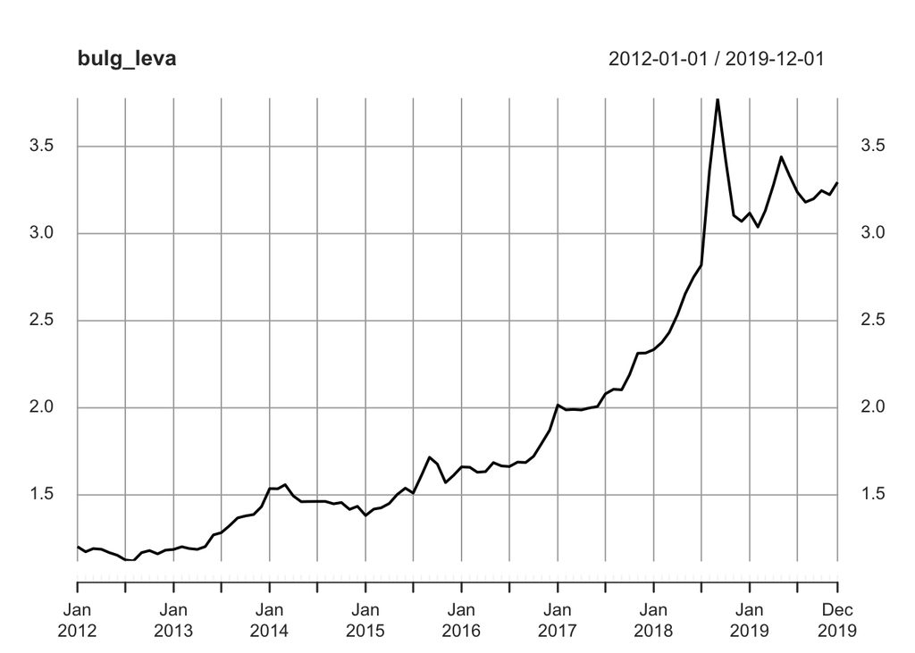

```r
veriler <- the_data[,2:8]
col_names_vector <- c("bulgar_ziyaretci", "paki_ziyaretci", "kuveyt_ziyaretci", "yab_sey_gelir", "b_leva_oran", "p_rupi_oran", "k_dinar_oran")
colnames(veriler) <- col_names_vector
sonveri <- xts(veriler, order.by = date_ver)
bulg_ziy<- sonveri[, c("bulgar_ziyaretci")]
bulg_leva <- sonveri[, c("b_leva_oran")]
plot(bulg_leva)
```

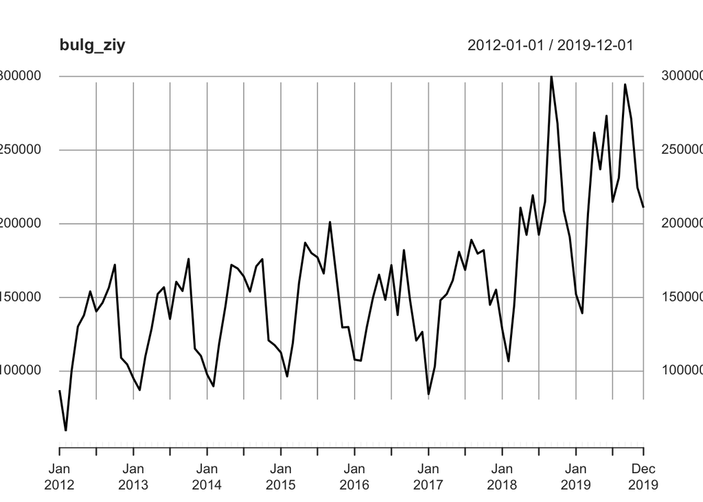

```r
plot(bulg_ziy)
```

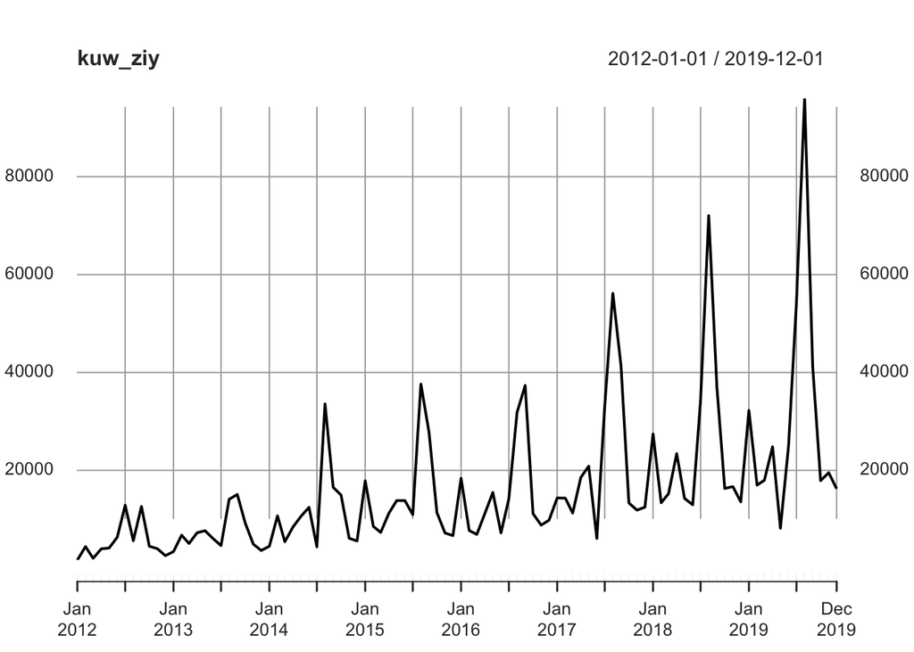

```r
kuw_ziy<- sonveri[, c("kuveyt_ziyaretci")]
kuw_dinar <- sonveri[, c("k_dinar_oran")]
plot(kuw_ziy)
```

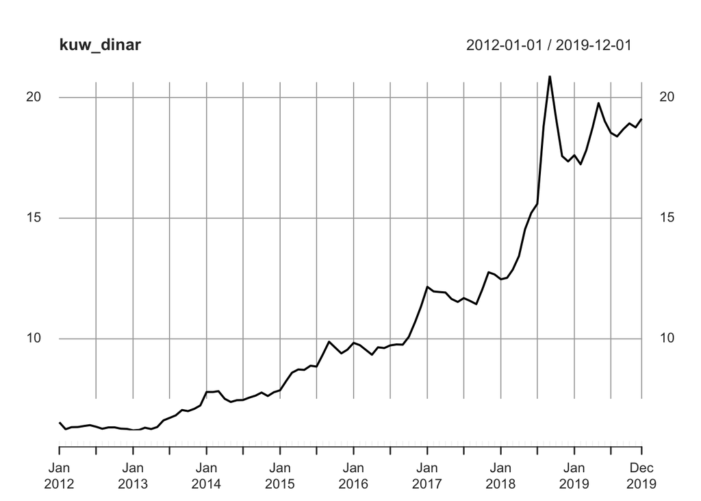

```r
plot(kuw_dinar)
```

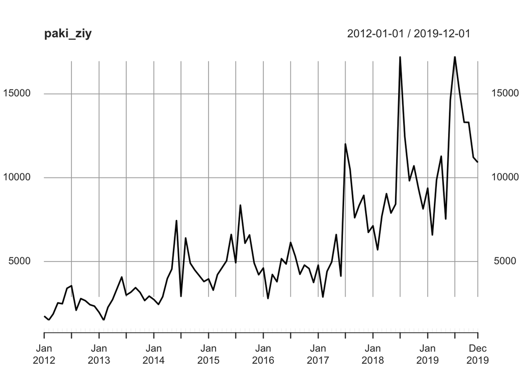

```r
paki_ziy<- sonveri[, c("paki_ziyaretci")]
paki_rupi <- sonveri[, c("p_rupi_oran")]
plot(paki_ziy)
```

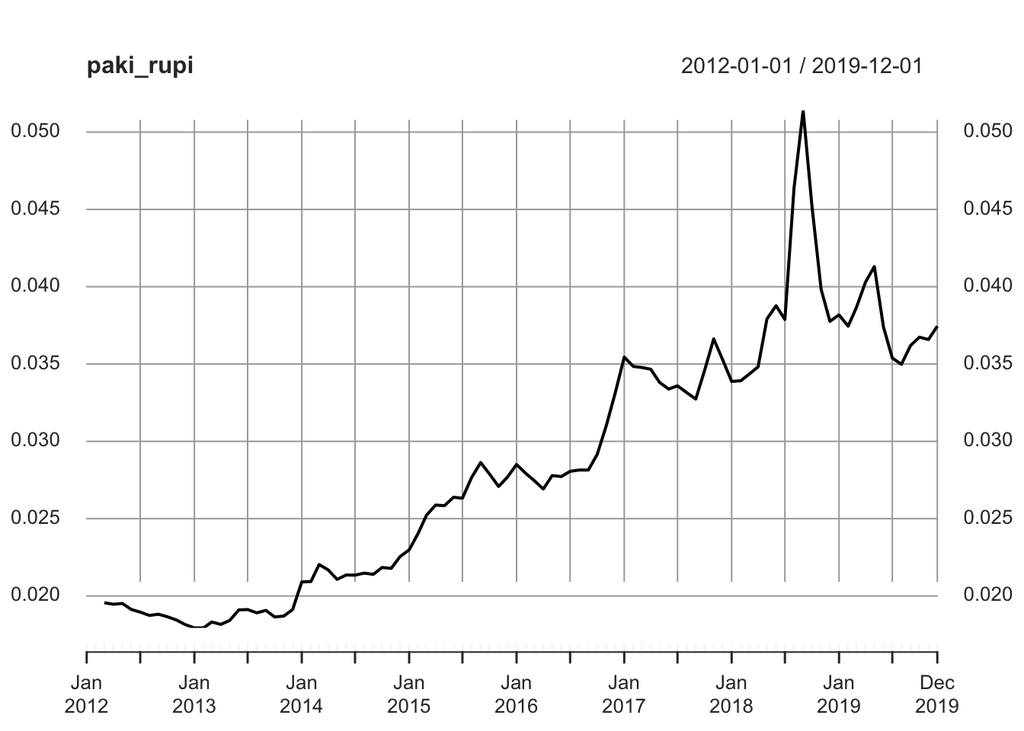

```r
plot(paki_rupi)
```

The script of my R-code can be reached here: https://github.com/BU-IE-360/spring20-ahmetunler/blob/master/Files/HW1%20script.R